# Practical Machine Learning Course Project

Ioannis Labrakis

# Overview

Using devices such as Jawbone Up, Nike FuelBand, and Fitbit it is now possible to collect a large amount of data about personal activity relatively inexpensively. These type of devices are part of the quantified self movement – a group of enthusiasts who take measurements about themselves regularly to improve their health, to find patterns in their behavior, or because they are tech geeks. One thing that people regularly do is quantify how much of a particular activity they do, but they rarely quantify how well they do it. In this project, the goal will be to use data from accelerometers on the belt, forearm, arm, and dumbell of 6 participants.

The data for this project come from this source: http://web.archive.org/web/20161224072740/http:/groupware.les.inf.puc-rio.br/har

The training data for this project are available here:

https://d396qusza40orc.cloudfront.net/predmachlearn/pml-training.csv

The test data are available here:

https://d396qusza40orc.cloudfront.net/predmachlearn/pml-testing.csv

The goal of this project is to predict the manner in which they did the exercise. This is the “classe” variable in the training set.

The dataset used for this project were provided from Ugulino, W.; Cardador, D.; Vega, K.; Velloso, E.; Milidiu, R.; Fuks, H.Wearable Computing: Accelerometers’ Data Classification of Body Postures and Movements

# Importing and processing the data

```r
#load required packages
library(caret)
library(rpart)
library(rattle)
library(randomForest)
library(gbm)
#loading the data
training = read.csv("C:/Users/Giannis/Desktop/Data science Specialization/8.Practical machine learning/course project/pml-training.csv",header = TRUE)
testing = read.csv("C:/Users/Giannis/Desktop/Data science Specialization/8.Practical machine learning/course project/pml-testing.csv",header = TRUE)
dim(training)
```

```
## [1] 19622   160
```

```r
dim(testing)
```

```
## [1]  20 160
```

Observing the two datasets it was found that there were some columns including only missing values. Additionally, the first seven variables iclude information about the people participated in the test, so they are irrelevant with the model.

```r
#remove columns with NA values
training_clean <- training[, colSums(is.na(training)) == 0]
testing_clean <- testing[, colSums(is.na(testing)) == 0]

#remove the first seven variables
training_clean <- training_clean[,-c(1:7)]
testing_clean <- testing_clean[,-c(1:7)]
dim(training_clean)
```

```
## [1] 19622    86
```

```r
dim(testing_clean)
```

```
## [1] 20 53
```

After cleaning the data, a partition of the training set was made by splitting the training data into 70% as train data and 30% as test data.

```r
set.seed(358)
inTrain <- createDataPartition(training_clean$classe, p = 0.70, list= FALSE)
trainData <- training_clean[inTrain,]
testingData <- training_clean[-inTrain,]
summary(trainData)
```

```
##    roll_belt        pitch_belt          yaw_belt       total_accel_belt
##  Min.   :-28.80   Min.   :-55.8000   Min.   :-179.00   Min.   : 1.00
##  1st Qu.:  1.10   1st Qu.:  1.6600   1st Qu.: -88.20   1st Qu.: 3.00
##  Median :114.00   Median :  5.2300   Median : -12.50   Median :17.00
##  Mean   : 64.65   Mean   :  0.2571   Mean   : -10.72   Mean   :11.34
##  3rd Qu.:123.00   3rd Qu.: 15.2000   3rd Qu.:  13.60   3rd Qu.:18.00
##  Max.   :162.00   Max.   : 60.2000   Max.   : 179.00   Max.   :28.00
##
##  kurtosis_roll_belt kurtosis_picth_belt kurtosis_yaw_belt
##           :13454             :13454            :13454
##  #DIV/0!  :    7    #DIV/0!  :   22     #DIV/0!:  283
##  -0.016850:    1    -0.150950:    3
##  -0.021024:    1    -1.750749:    3
##  -0.025513:    1    -1.851307:    3
##  -0.033935:    1    -2.060105:    3
##  (Other)  :  272    (Other)  :  249
##  skewness_roll_belt skewness_roll_belt.1 skewness_yaw_belt  max_yaw_belt
##           :13454             :13454             :13454            :13454
##  #DIV/0!  :    7    #DIV/0!  :   22      #DIV/0!:  283     -1.4   :   24
##  0.000000 :    3    -2.156553:    3                        -1.2   :   21
##  -0.003095:    1    -3.072669:    3                        -1.1   :   20
##  -0.010002:    1    -6.324555:    3                        -0.9   :   18
##  -0.014020:    1    0.000000 :    3                        -1.5   :   15
##  (Other)  :  270    (Other)  :  249                        (Other):  185
##   min_yaw_belt   amplitude_yaw_belt  gyros_belt_x        gyros_belt_y
##         :13454          :13454      Min.   :-1.000000   Min.   :-0.64000
##  -1.4   :   24   #DIV/0!:    7      1st Qu.:-0.050000   1st Qu.: 0.00000
##  -1.2   :   21   0.00   :    9      Median : 0.030000   Median : 0.02000
##  -1.1   :   20   0.0000 :  267      Mean   :-0.006057   Mean   : 0.03972
##  -0.9   :   18                      3rd Qu.: 0.110000   3rd Qu.: 0.11000
##  -1.5   :   15                      Max.   : 2.220000   Max.   : 0.64000
##  (Other):  185
##   gyros_belt_z      accel_belt_x     accel_belt_y     accel_belt_z
##  Min.   :-1.4600   Min.   :-83.00   Min.   :-69.00   Min.   :-268.00
##  1st Qu.:-0.2000   1st Qu.:-21.00   1st Qu.:  3.00   1st Qu.:-162.00
##  Median :-0.1000   Median :-14.00   Median : 36.00   Median :-153.00
##  Mean   :-0.1302   Mean   : -5.49   Mean   : 30.22   Mean   : -72.94
##  3rd Qu.:-0.0200   3rd Qu.: -5.00   3rd Qu.: 61.00   3rd Qu.:  27.00
##  Max.   : 1.6200   Max.   : 81.00   Max.   :149.00   Max.   : 105.00
##
```

[output cut: 137 more lines]

```
##  Min.   :-632.0   Min.   :-410.00   Min.   :-1280.0   Min.   :-892.0
##  1st Qu.:  56.0   1st Qu.:-181.00   1st Qu.: -617.0   1st Qu.:   2.0
##  Median : 201.0   Median : -38.00   Median : -377.0   Median : 592.0
##  Mean   : 164.1   Mean   : -54.54   Mean   : -312.6   Mean   : 381.8
##  3rd Qu.: 312.0   3rd Qu.:  26.00   3rd Qu.:  -72.0   3rd Qu.: 738.0
##  Max.   : 591.0   Max.   : 285.00   Max.   :  672.0   Max.   :1480.0
##
##  magnet_forearm_z classe
##  Min.   :-973.0   A:3906
##  1st Qu.: 183.0   B:2658
##  Median : 509.0   C:2396
##  Mean   : 390.5   D:2252
##  3rd Qu.: 653.0   E:2525
##  Max.   :1090.0
##
```

It was found that there were a lot variables near zero and they were removed.

```r
#remove near zero variables
nzv <- nearZeroVar(trainData)
trainData <- trainData[, -nzv]
testingData  <- testingData [, -nzv]
dim(trainData)
```

```
## [1] 13737    53
```

```r
dim(testingData)
```

```
## [1] 5885   53
```

# Building the models

For this project there were used three different models and validated which of them provides the best accuracy. Those models were classification tree, gradient boosting and random forests. For improving the efficiency and limit overfitting, cross validation technique was used with 3 folds. The number of folds could be bigger for better accuracy, but the time needed to process it was taking too long.

## Classification tree

[figure not shown]

```r
#setting cross validation folds to 10
trControl <- trainControl(method="cv", number=3)
modelClassTree <- train(classe~., data=trainData, method="rpart", trControl=trControl)

#plotting the classification tree model
fancyRpartPlot(modelClassTree$finalModel)
```

```r
#prediction with classification tree
pred1 <- predict(modelClassTree,newdata=testingData)
confMatrixClassTree <- confusionMatrix(testingData $classe,pred1)
confMatrixClassTree$table
```

```
##           Reference
## Prediction    A    B    C    D    E
##          A 1517   26  127    0    4
##          B  469  393  277    0    0
##          C  471   34  521    0    0
##          D  410  171  383    0    0
##          E  137  164  283    0  498
```

```r
#accuracy
confMatrixClassTree$overall[1]
```

```
## Accuracy
## 0.497706
```

## gradient boosting

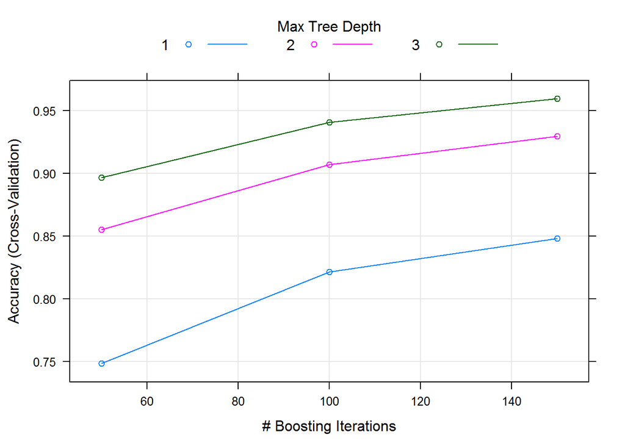

```r
modelgbm <- train(classe~., data = trainData, method="gbm",trControl = trControl, verbose = FALSE)

#plotting the gbm model
plot(modelgbm)
```

```r
#prediction with gbm model
pred2 <- predict(modelgbm,newdata=testingData)

confMatrixgbm <- confusionMatrix(testingData$classe,pred2)
confMatrixgbm$table
```

```
##           Reference
## Prediction    A    B    C    D    E
##          A 1647   21    3    2    1
##          B   45 1063   27    1    3
##          C    0   24  984   14    4
##          D    3    2   34  917    8
##          E    2   18   11   15 1036
```

```r
#accuracy
confMatrixgbm$overall[1]
```

```
##  Accuracy
## 0.9595582
```

The accuracy of gbm method was high enough at about 96% and therefore the out of sample error is about 4%.

## Random forests

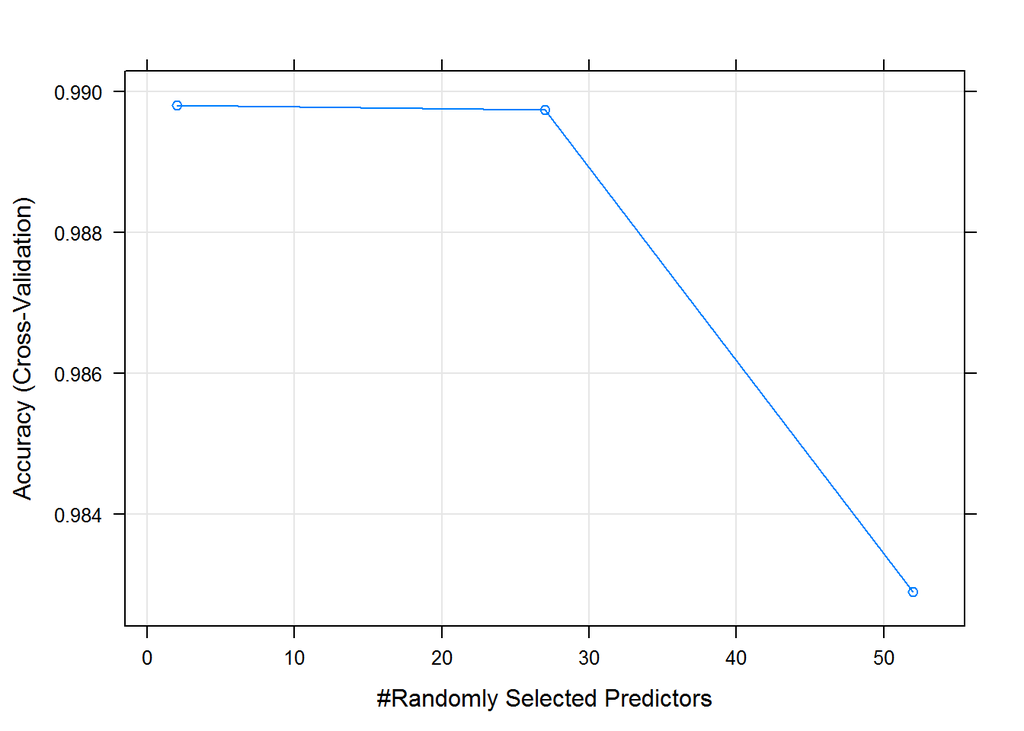

```r
modelrf <- train(classe~., data=trainData, method="rf", trControl=trControl)

#plotting random forest
plot(modelrf)
```

```r
#prediction with rf model
pred3 <- predict(modelrf,newdata=testingData)

confMatrixrf <- confusionMatrix(testingData$classe,pred3)
confMatrixrf$table
```

```
##           Reference
## Prediction    A    B    C    D    E
##          A 1671    3    0    0    0
##          B    6 1132    1    0    0
##          C    0   11 1015    0    0
##          D    0    0   19  944    1
##          E    0    0    2    2 1078
```

```r
#accuracy
confMatrixrf$overall[1]
```

```
##  Accuracy
## 0.9923534
```

The random forest accuracy 99.2% and the out of sample error is about 0.8%

# Conclusion

As it was shown above the random forest model is the best out the three models. So it used to predict the values of classe for the test data set.

```r
testPred <- predict(modelrf,newdata = testing_clean)
testPred
```

```
##  [1] B A B A A E D B A A B C B A E E A B B B
## Levels: A B C D E
```